# Machine Learning Assignment

Christian Wagner

Thursday, August 20, 2015

In this assignment we use data from accelerometers attached to different body parts to build a ML model that predicts the manner a certain excercise (barbell lift) was performed. For more information see the website of the group that originally collected and analyzed the data: http://groupware.les.inf.puc-rio.br/har

We use the caret package for this assignment.

```r
library(caret)
library(randomForest)
```

## Loading and Cleaning the Data

We start by loading the data and converting empty entries and #DIV/0! to NAs.

```r
dat<-read.csv("pml-training.csv",na.strings=c("NA","","#DIV/0!"))
str(dat)
```

```
## 'data.frame':    19622 obs. of  160 variables:
##  $ X                       : int  1 2 3 4 5 6 7 8 9 10 ...
##  $ user_name               : Factor w/ 6 levels "adelmo","carlitos",..: 2 2 2 2 2 2 2 2 2 2 ...
##  $ raw_timestamp_part_1    : int  1323084231 1323084231 1323084231 1323084232 1323084232 1323084232 1323084232 1323084232 1323084232 1323084232 ...
##  $ raw_timestamp_part_2    : int  788290 808298 820366 120339 196328 304277 368296 440390 484323 484434 ...
##  $ cvtd_timestamp          : Factor w/ 20 levels "02/12/2011 13:32",..: 9 9 9 9 9 9 9 9 9 9 ...
##  $ new_window              : Factor w/ 2 levels "no","yes": 1 1 1 1 1 1 1 1 1 1 ...
##  $ num_window              : int  11 11 11 12 12 12 12 12 12 12 ...
##  $ roll_belt               : num  1.41 1.41 1.42 1.48 1.48 1.45 1.42 1.42 1.43 1.45 ...
##  $ pitch_belt              : num  8.07 8.07 8.07 8.05 8.07 8.06 8.09 8.13 8.16 8.17 ...
##  $ yaw_belt                : num  -94.4 -94.4 -94.4 -94.4 -94.4 -94.4 -94.4 -94.4 -94.4 -94.4 ...
##  $ total_accel_belt        : int  3 3 3 3 3 3 3 3 3 3 ...
##  $ kurtosis_roll_belt      : num  NA NA NA NA NA NA NA NA NA NA ...
##  $ kurtosis_picth_belt     : num  NA NA NA NA NA NA NA NA NA NA ...
##  $ kurtosis_yaw_belt       : logi  NA NA NA NA NA NA ...
```

[output cut: 86 more lines]

As we see, the data set contains a few bookkeeping variables that we should not use for the prediction. There are also many measurement variables with (almost) all values being NAs.

First, we remove the bookkeeping variables,

```r
dat<-dat[,-(1:7)]
```

Next we count the number of NAs per variable

```r
sumOfNA <- apply(dat, 2, function(x) {sum(is.na(x))})
print(sumOfNA)
```

```
##                roll_belt               pitch_belt                 yaw_belt
##                        0                        0                        0
##         total_accel_belt       kurtosis_roll_belt      kurtosis_picth_belt
##                        0                    19226                    19248
##        kurtosis_yaw_belt       skewness_roll_belt     skewness_roll_belt.1
##                    19622                    19225                    19248
##        skewness_yaw_belt            max_roll_belt           max_picth_belt
##                    19622                    19216                    19216
##             max_yaw_belt            min_roll_belt           min_pitch_belt
##                    19226                    19216                    19216
##             min_yaw_belt      amplitude_roll_belt     amplitude_pitch_belt
##                    19226                    19216                    19216
##       amplitude_yaw_belt     var_total_accel_belt            avg_roll_belt
##                    19226                    19216                    19216
##         stddev_roll_belt            var_roll_belt           avg_pitch_belt
##                    19216                    19216                    19216
##        stddev_pitch_belt           var_pitch_belt             avg_yaw_belt
##                    19216                    19216                    19216
##          stddev_yaw_belt             var_yaw_belt             gyros_belt_x
##                    19216                    19216                        0
##             gyros_belt_y             gyros_belt_z             accel_belt_x
##                        0                        0                        0
##             accel_belt_y             accel_belt_z            magnet_belt_x
##                        0                        0                        0
##            magnet_belt_y            magnet_belt_z                 roll_arm
##                        0                        0                        0
##                pitch_arm                  yaw_arm          total_accel_arm
##                        0                        0                        0
##            var_accel_arm             avg_roll_arm          stddev_roll_arm
##                    19216                    19216                    19216
##             var_roll_arm            avg_pitch_arm         stddev_pitch_arm
##                    19216                    19216                    19216
##            var_pitch_arm              avg_yaw_arm           stddev_yaw_arm
##                    19216                    19216                    19216
##              var_yaw_arm              gyros_arm_x              gyros_arm_y
##                    19216                        0                        0
##              gyros_arm_z              accel_arm_x              accel_arm_y
##                        0                        0                        0
##              accel_arm_z             magnet_arm_x             magnet_arm_y
##                        0                        0                        0
```

[output cut: 47 more lines]

```
##                    19216                    19216                    19300
##      total_accel_forearm        var_accel_forearm         avg_roll_forearm
##                        0                    19216                    19216
##      stddev_roll_forearm         var_roll_forearm        avg_pitch_forearm
##                    19216                    19216                    19216
##     stddev_pitch_forearm        var_pitch_forearm          avg_yaw_forearm
##                    19216                    19216                    19216
##       stddev_yaw_forearm          var_yaw_forearm          gyros_forearm_x
##                    19216                    19216                        0
##          gyros_forearm_y          gyros_forearm_z          accel_forearm_x
##                        0                        0                        0
##          accel_forearm_y          accel_forearm_z         magnet_forearm_x
##                        0                        0                        0
##         magnet_forearm_y         magnet_forearm_z                   classe
##                        0                        0                        0
```

From the above numbers, it’s clear that either variables have no NAs at all or almost all entries are NAs. We therefore keep only variables with less than 90% NAs (for this data set, this results in removing all NAs):

```r
dat_reduced <- dat[,which(sumOfNA<0.9*dim(dat)[1])]
```

This reduced the data set to 52 features and the outcome (“classe”):

```r
dim(dat_reduced)
```

```
## [1] 19622    53
```

## Training the models

For later validation of the model, we split the data into a training set and a validation set:

```r
set.seed(20815)
inTrain <- createDataPartition(dat_reduced$classe, p=0.7, list=F)
training <- dat_reduced[inTrain,]
validation <- dat_reduced[-inTrain,]
```

Now, let’s start with a simple and fast model, we choose the quadratic discriminant analysis (QDA) method using k-fold cross validation:

```r
ctrl <- trainControl(method="cv", number=5)
model_qda<-train(classe ~ ., data=training, method="qda", trControl=ctrl)
model_qda
```

```
## Quadratic Discriminant Analysis
##
## 13737 samples
##    52 predictor
##     5 classes: 'A', 'B', 'C', 'D', 'E'
##
## No pre-processing
## Resampling: Cross-Validated (5 fold)
## Summary of sample sizes: 10990, 10990, 10988, 10990, 10990
## Resampling results
##
##   Accuracy   Kappa      Accuracy SD  Kappa SD
##   0.8892772  0.8601707  0.003605973  0.004679474
##
##
```

The estimated accuracy of 89% is not bad, but we can probably improve the prediction accuracy by a more complex model like a Random Forest model with k-fold cross validation:

```r
ctrl <- trainControl(method="cv", number=5)
model_rf<-train(classe ~ ., data=training, method="rf", trControl=ctrl)
model_rf
```

```
## Random Forest
##
## 13737 samples
##    52 predictor
##     5 classes: 'A', 'B', 'C', 'D', 'E'
##
## No pre-processing
## Resampling: Cross-Validated (5 fold)
## Summary of sample sizes: 10990, 10990, 10990, 10989, 10989
## Resampling results across tuning parameters:
##
##   mtry  Accuracy   Kappa      Accuracy SD  Kappa SD
##    2    0.9910461  0.9886723  0.001866663  0.002362221
##   27    0.9904636  0.9879363  0.001419758  0.001797018
##   52    0.9820185  0.9772525  0.007592491  0.009605559
##
## Accuracy was used to select the optimal model using  the largest value.
## The final value used for the model was mtry = 2.
```

Now the estimated accuracy is almost 100%.

```r
model_rf$finalModel
```

```
##
## Call:
##  randomForest(x = x, y = y, mtry = param$mtry)
##                Type of random forest: classification
##                      Number of trees: 500
## No. of variables tried at each split: 2
##
##         OOB estimate of  error rate: 0.74%
## Confusion matrix:
##      A    B    C    D    E  class.error
## A 3903    2    0    0    1 0.0007680492
## B   19 2631    8    0    0 0.0101580135
## C    0   19 2376    1    0 0.0083472454
## D    0    0   42 2208    2 0.0195381883
## E    0    0    2    5 2518 0.0027722772
```

The Out-of-Bag error rate is below 1%.

The most important variables are

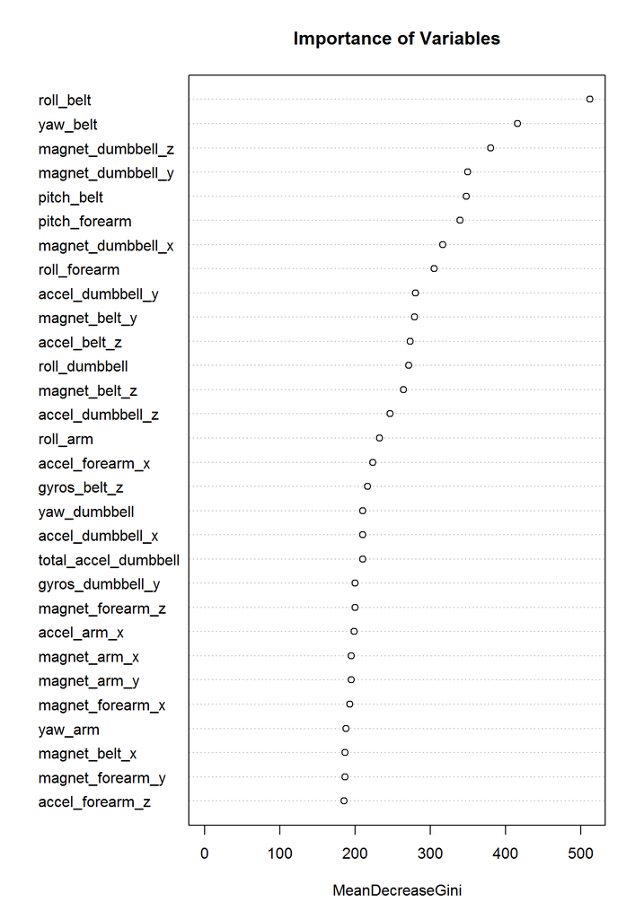

```r
varImpPlot(model_rf$finalModel, main="Importance of Variables")
```

## Out-of-sample error

In order to confirm the estimated accuracy, we apply the model to the validation data set and look at the confusion matrix.

```r
pred_rf<-predict(model_rf,validation)
confusionMatrix(pred_rf,validation$classe)
```

```
## Confusion Matrix and Statistics
##
##           Reference
## Prediction    A    B    C    D    E
##          A 1673    7    0    0    0
##          B    1 1127   13    0    0
##          C    0    5 1012   15    0
##          D    0    0    1  947    1
##          E    0    0    0    2 1081
##
## Overall Statistics
##
##                Accuracy : 0.9924
##                  95% CI : (0.9898, 0.9944)
##     No Information Rate : 0.2845
##     P-Value [Acc > NIR] : < 2.2e-16
##
##                   Kappa : 0.9903
##  Mcnemar's Test P-Value : NA
##
## Statistics by Class:
##
##                      Class: A Class: B Class: C Class: D Class: E
## Sensitivity            0.9994   0.9895   0.9864   0.9824   0.9991
## Specificity            0.9983   0.9971   0.9959   0.9996   0.9996
## Pos Pred Value         0.9958   0.9877   0.9806   0.9979   0.9982
## Neg Pred Value         0.9998   0.9975   0.9971   0.9966   0.9998
## Prevalence             0.2845   0.1935   0.1743   0.1638   0.1839
## Detection Rate         0.2843   0.1915   0.1720   0.1609   0.1837
## Detection Prevalence   0.2855   0.1939   0.1754   0.1613   0.1840
## Balanced Accuracy      0.9989   0.9933   0.9911   0.9910   0.9993
```

Indeed, the out-of-sample accuracy is over 99% and, hence, the out-of-sample error is below 1%.

## Testing Sample Predictions

```r
testing<-read.csv("pml-testing.csv",na.strings=c("NA","","#DIV/0!"))
predict(model_rf,testing)
```

```
##  [1] B A B A A E D B A A B C B A E E A B B B
## Levels: A B C D E
```

## Conclusion

The Random Forest model is highly accurate at predicting the 5 different types of movement.